# Smoothing and Regression Splines

Joan Oliveras Torra, Odysseas Kyparissis, Louis Tichelman

2023-11-28

The file `bikes.Washington.Rdata` contains information on the bike-sharing rental service in Washington D.C., USA, corresponding to years `2011` and `2012`. This file contains only one data frame, `bikes`, with `731` rows (one for each day of years 2011 and 2012, that was a leap year) and `9` columns:

```r
load("bikes.Washington.Rdata")
summary(bikes)
```

```
##     instant            yr             dayyr          weekday
##  Min.   :  1.0   Min.   :0.0000   Min.   :  1.0   Min.   :0.000
##  1st Qu.:183.5   1st Qu.:0.0000   1st Qu.: 92.0   1st Qu.:1.000
##  Median :366.0   Median :1.0000   Median :183.0   Median :3.000
##  Mean   :366.0   Mean   :0.5007   Mean   :183.3   Mean   :2.997
##  3rd Qu.:548.5   3rd Qu.:1.0000   3rd Qu.:274.5   3rd Qu.:5.000
##  Max.   :731.0   Max.   :1.0000   Max.   :366.0   Max.   :6.000
##    workingday         temp             hum          windspeed
##  Min.   :0.000   Min.   : 2.424   Min.   : 0.00   Min.   : 1.500
##  1st Qu.:0.000   1st Qu.:13.820   1st Qu.:52.00   1st Qu.: 9.042
##  Median :1.000   Median :20.432   Median :62.67   Median :12.125
##  Mean   :0.684   Mean   :20.311   Mean   :62.79   Mean   :12.763
##  3rd Qu.:1.000   3rd Qu.:26.872   3rd Qu.:73.02   3rd Qu.:15.625
##  Max.   :1.000   Max.   :35.328   Max.   :97.25   Max.   :34.000
##       cnt
##  Min.   :  22
##  1st Qu.:3152
##  Median :4548
##  Mean   :4504
##  3rd Qu.:5956
##  Max.   :8714
```

From the summary and a brief inspection of the dataset the following information is obtained:

- `instant`: Row index, ranging from 1 to 731.
- `yr`: Year (0: 2011, 1: 2012).
- `dayyr`: Day of the year (1 to 365 for 2011, 1 to 366 for 2012).
- `weekday`: Day of the week (0 for Sunday, 1 for Monday, …, 6 for Saturday).
- `workingday`: If the day is neither a weekend nor a holiday, it is 1; otherwise, it is 0.
- `temp`: Temperature in Celsius.
- `hum`: Humidity in percentage (%).
- `windspeed`: Wind speed in miles per hour.
- `cnt`: Count of total rental bikes. In this assignment, we consider this variable as continuous.

# Question 1: Cubic regression spline

The model we want to estimate is: ($cnt \sim m(instant)$)

## Model fitting

```r
# Sort dataframe based on the "instant" column
df <- bikes[order(bikes$instant), ]
spline_fit <- smooth.spline(df$instant, df$cnt, cv = FALSE)
spline_fit
```

```
## Call:
## smooth.spline(x = df$instant, y = df$cnt, cv = FALSE)
##
## Smoothing Parameter  spar= 0.24802  lambda= 1.005038e-07 (11 iterations)
## Equivalent Degrees of Freedom (Df): 93.34091
## Penalized Criterion (RSS): 470358491
## GCV: 845608.3
```

## Extraction of results

```r
lambda <- spline_fit$lambda
df <- spline_fit$df
num_knots <- spline_fit$fit$nk
fitted_values <- predict(spline_fit, bikes$instant)$y
```

## Display of results

### (a), (b), (c)

```r
# Display the results
cat("a) The chosen penalty parameter λ is:", lambda, "\n")
```

```
## a) The chosen penalty parameter λ is: 1.005038e-07
```

```r
cat("b) The corresponding equivalent number of degrees of freedom df is:", df, "\n")
```

```
## b) The corresponding equivalent number of degrees of freedom df is: 93.34091
```

```r
cat("c) The number of knots used is:", num_knots, "\n")
```

```
## c) The number of knots used is: 136
```

### (d) Graphic representation of the estimated regression function

The estimated regression function $\hat m(instant)$, together with the scatter plot of the real data is displayed in this section.

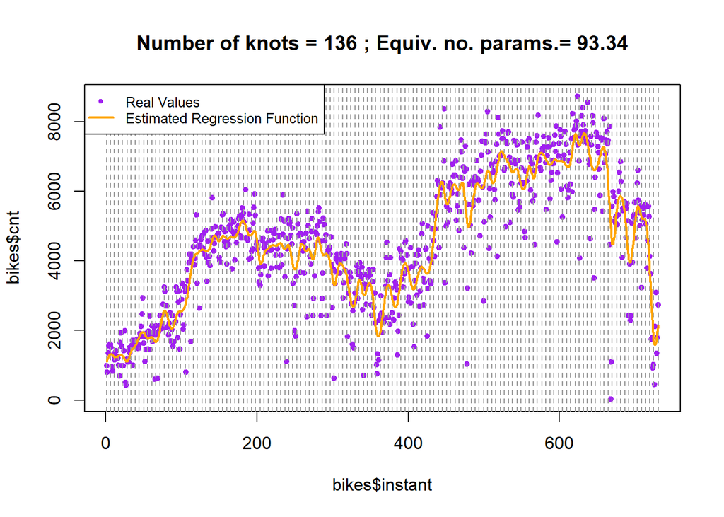

```r
plot(x = bikes$instant, y = bikes$cnt,
     main=paste("Number of knots =",num_knots,
                "; Equiv. no. params.=",round(df,2)), col = "purple", pch = 20)
abline(v=spline_fit$fit$min+spline_fit$fit$knot*spline_fit$fit$range, col=8, lty=2)
lines(spline_fit,col="orange",lwd=2)
# Add legend with adjusted position
legend("topleft", legend = c("Real Values", "Estimated Regression Function"), col = c("purple", "orange"), pch = c(20, NA), lwd = c(NA, 2), cex = 0.8)
```

# Question 2: Nonparametric logistic regression using splines with a IRWLS procedure

The following script (`IRWLS_logistic_regression.R`) includes the implementation of `logistic regression` by using a custom `Iteratively Re-Weighted Least Squares (IRWLS)` algorithm.

```r
# Source IRWLS_logistic_regression.R
source("IRWLS_logistic_regression.R")
```

The implementation is mainly performed from the function `logistic.IRWLS.splines` where its arguments are the explanatory variable $x$, the $0-1$ response variable $y$, the vector $x.new$ of new values of variable $x$ where we want to predict the probability of $y$ being $1$ given that $x$ is equal to $x.new$, the equivalent number of parameters (or model degrees of freedom) $df$, and the logical `plts` indicating if plots are desired or not.

## Creation of variable cnt.5000

```r
bikes$cnt.5000 <- ifelse(bikes$cnt >= 5000, 1, 0)
```

The following `barplot` provides an insight on the number of days with more or less than $5000$ rentals.

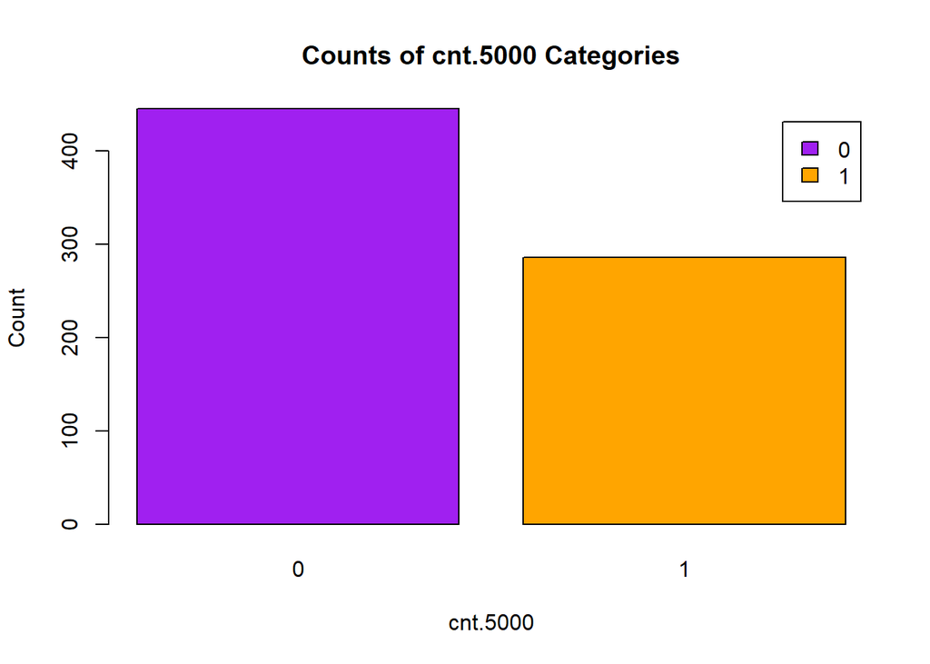

```r
# Plot the counts of each category using a bar plot
barplot(table(bikes$cnt.5000), main = "Counts of cnt.5000 Categories", xlab = "cnt.5000", ylab = "Count", col = c("purple", "orange"), legend = c("0", "1"))
```

## (a) Range of temperatures for probability of having more than 5000 rentals in a day is larger than 0.5

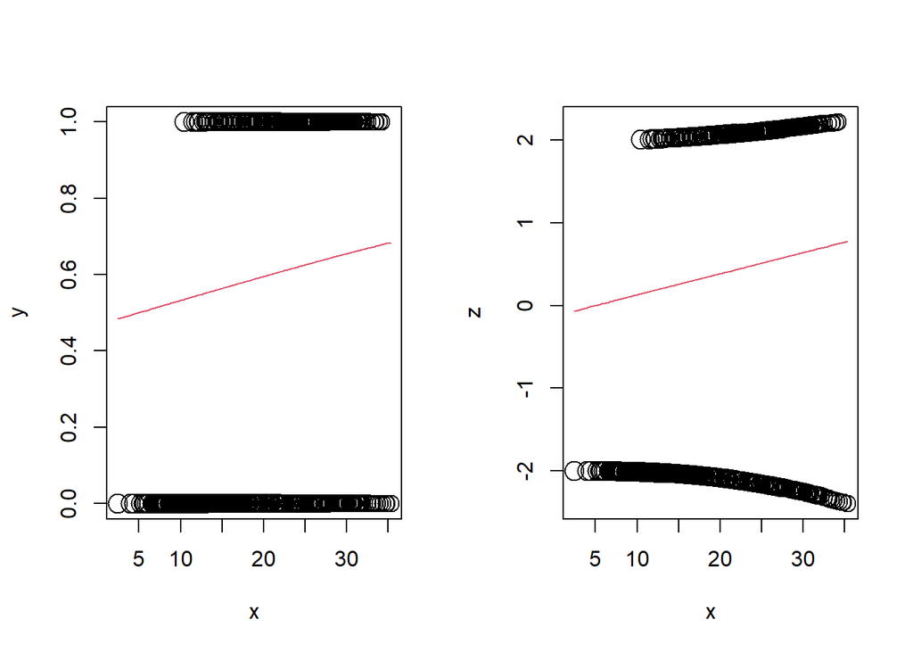

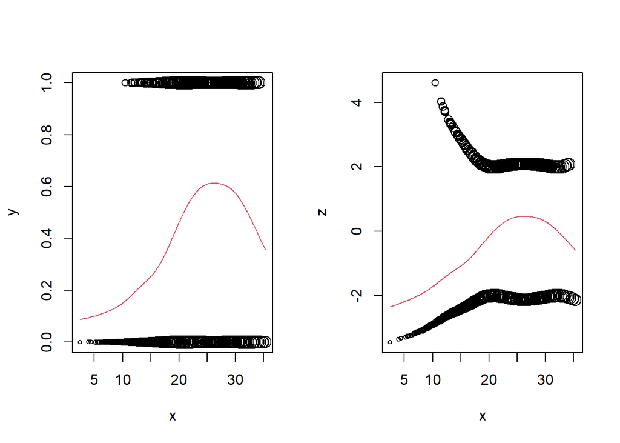

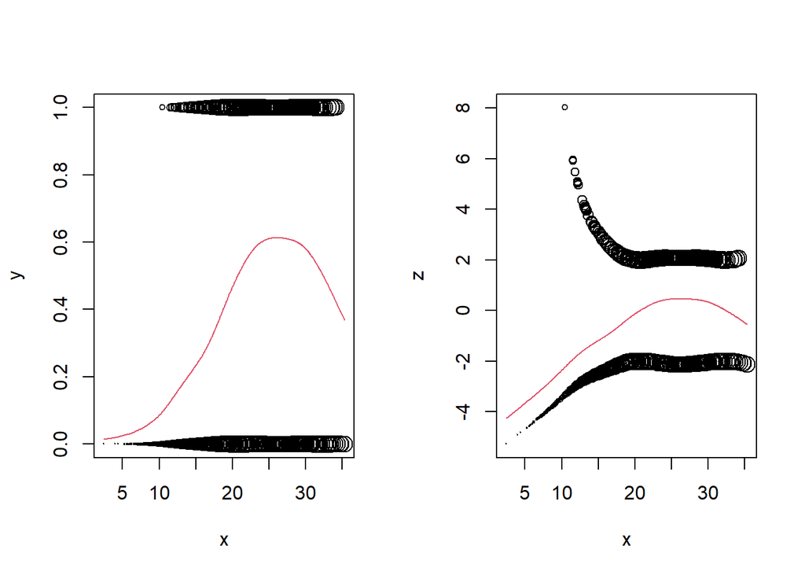

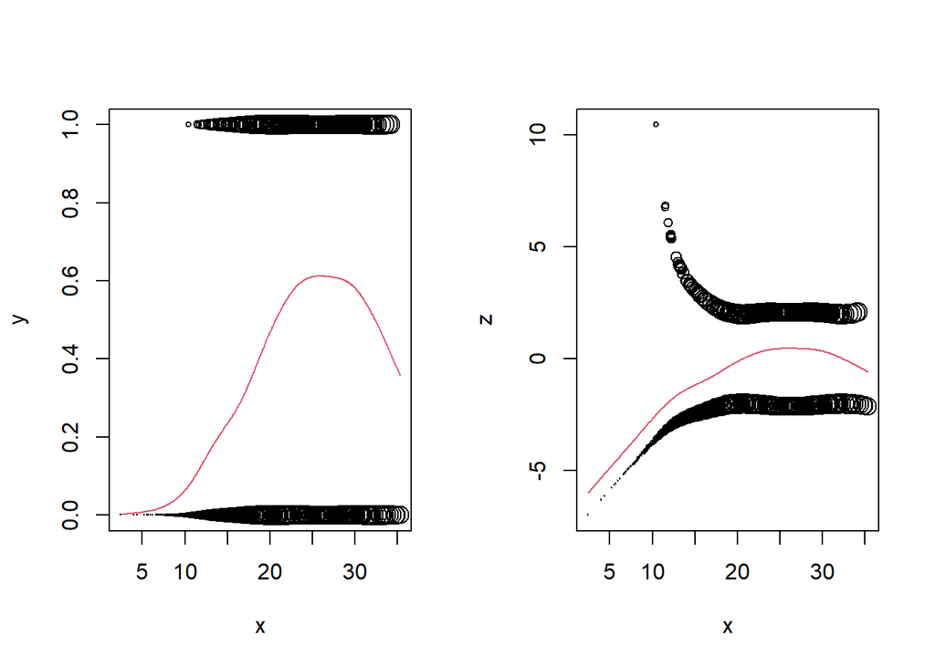

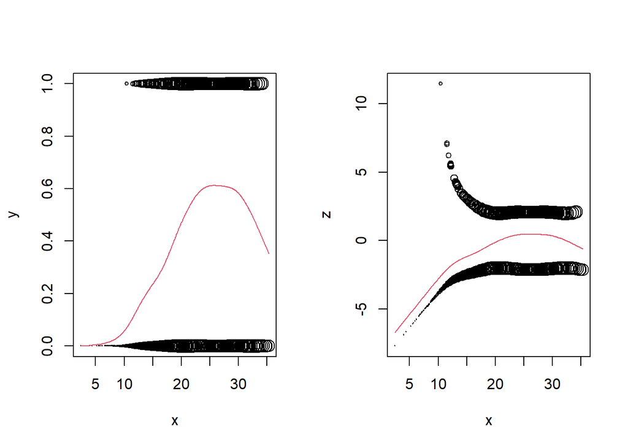

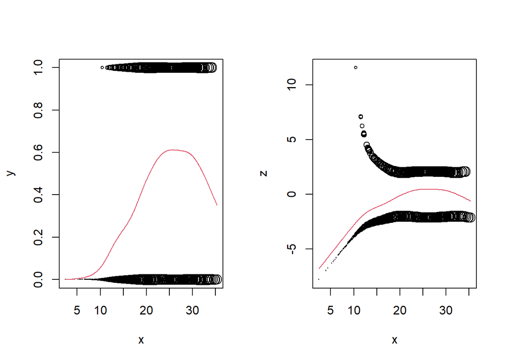

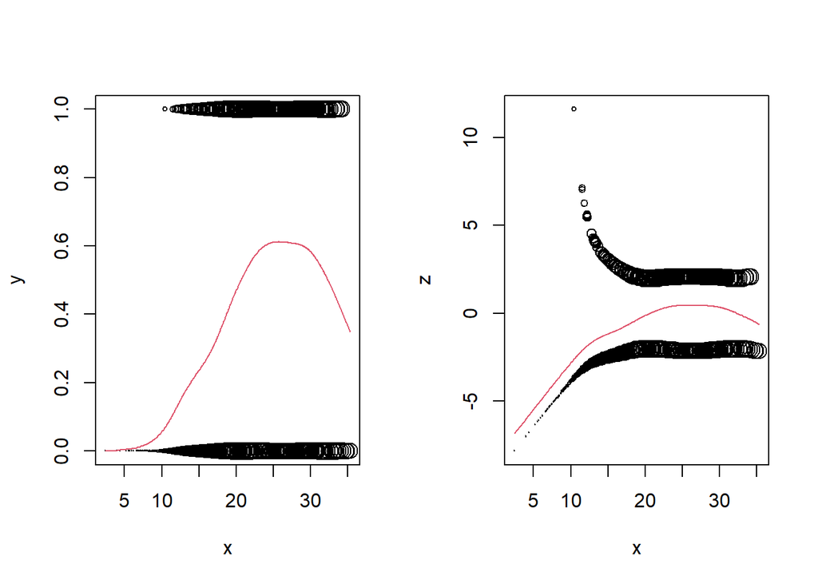

```r
# Fit non-parametric binary regression
# Sort dataframe based on the "temp" column
df <- bikes[order(bikes$temp), ]
logistic_spline_fit <- logistic.IRWLS.splines(x = df$temp, y = df$cnt.5000, df = 6, plts=TRUE)
```

```r
# Calculate the estimated probabilities for the given temperatures
predicted_probabilities <- logistic_spline_fit$fitted.values
```

```r
# Find the temperatures where Pr(cnt >= 5000|temp) is larger than 0.5
temperatures <- df$temp[predicted_probabilities > 0.5]
```

```r
# Display the range of temperatures
cat("The range of temperatures where Pr(cnt >= 5000|temp) is larger than 0.5 is: [",min(temperatures),",",max(temperatures), "]\n")
```

```
## The range of temperatures where Pr(cnt >= 5000|temp) is larger than 0.5 is: [ 20.73915 , 32.35585 ]
```

## (b) k-fold log-likelihood cross validation

```r
library(caret)

# Set of possible values for df
df.v <- seq(3, 15)

# Initialize variables to store cross-validation results
cv_results <- numeric(length(df.v))

# Perform k-fold log-likelihood cross-validation
set.seed(1234)  # Set seed for reproducibility

# Generate k-fold indices
k <- 5
folds <- createFolds(bikes$temp, k = k)

for (j in 1:length(df.v)){
  df = df.v[j]
  cv_log_likelihood = 0
  for (i in 1:k){
    x = bikes$temp[-folds[[i]]]
    x.new = bikes$temp[folds[[i]]]
    y = bikes$cnt.5000[-folds[[i]]]
    y.new = bikes$cnt.5000[folds[[i]]]
    model = logistic.IRWLS.splines(x=x, y=y, x.new = x.new, plts = F, df=df)
    pred = model$predicted.values
    valid_log_likelihood  = sum(y.new*log(pred) + (1-y.new)*log(1-pred))
    cv_log_likelihood = cv_log_likelihood + valid_log_likelihood
  }
  cv_results[j] = cv_log_likelihood
}

# Choose the df value that maximizes cross-validated log-likelihood
optimal_df <- df.v[which.max(cv_results)]
```

```r
# Display the cv_results data
cv_results
```

```
##  [1] -419.7981 -417.9374 -417.7056 -417.4951 -417.3822 -417.4655 -417.7289
##  [8] -418.1084 -418.5402 -418.9730 -419.3800 -419.7572 -420.1091
```

```r
# Display the optimal df value
cat("Optimal df:", optimal_df, "\n")
```

```
## Optimal df: 7
```

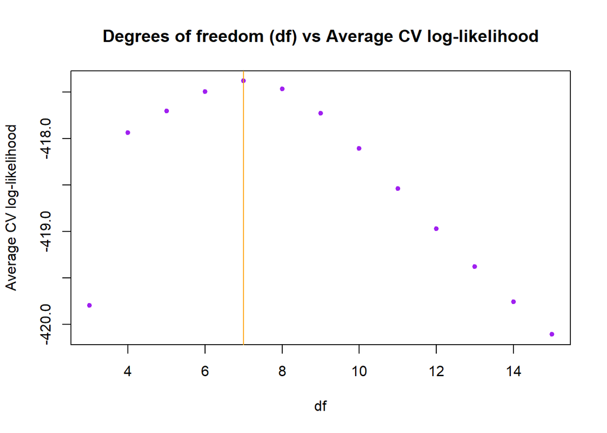

```r
plot(df.v, cv_results, main = "Degrees of freedom (df) vs Average CV log-likelihood", xlab = "df", ylab = "Average CV log-likelihood",  col = "purple", pch = 20)
abline(v = optimal_df, col = "orange")  # Assuming optimal_df is a vertical line
```

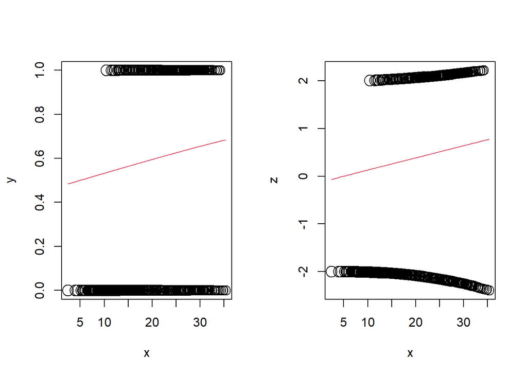

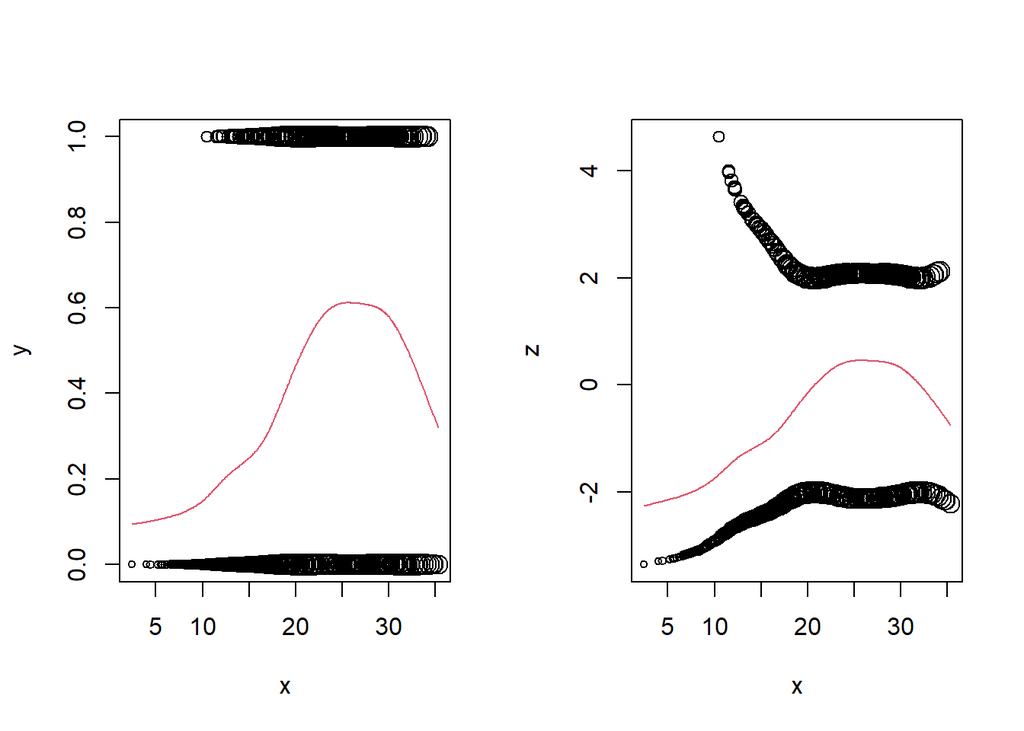

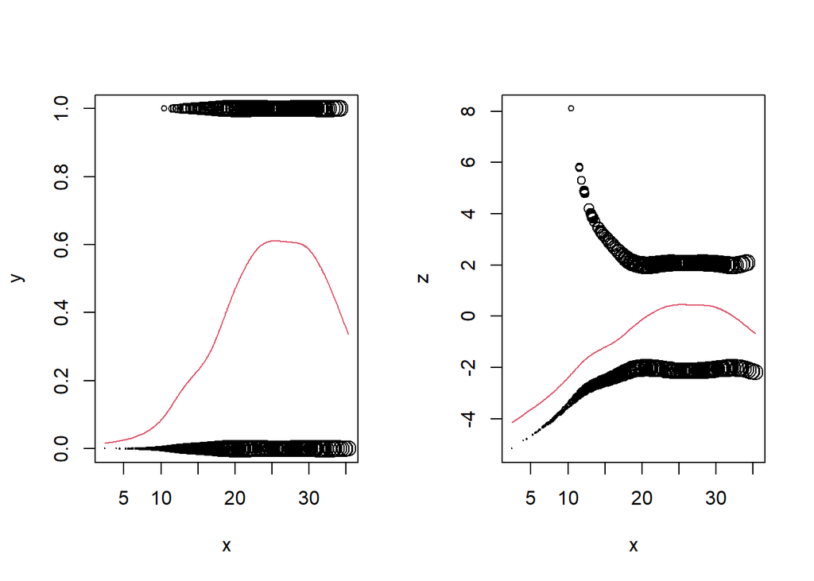

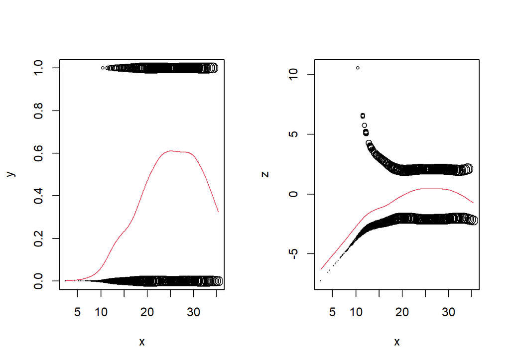

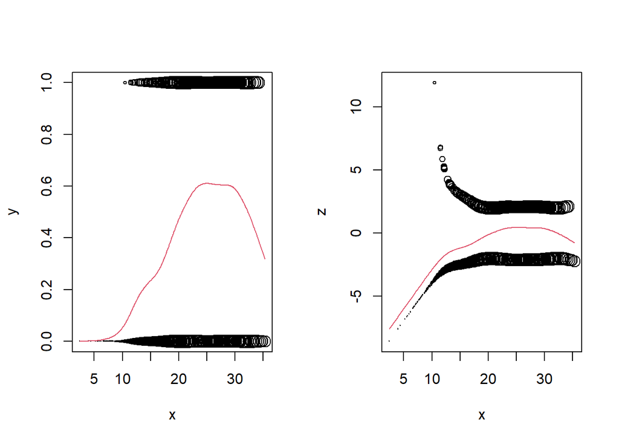

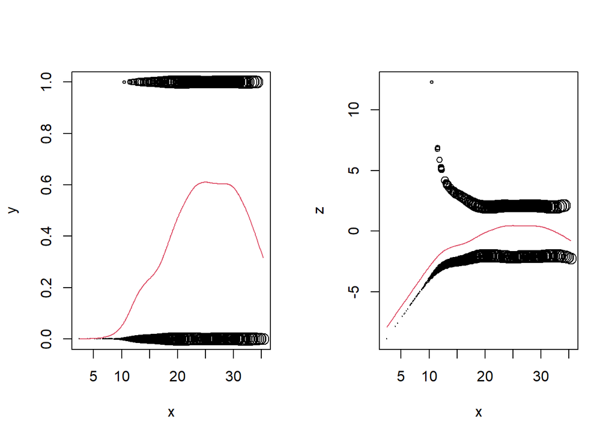

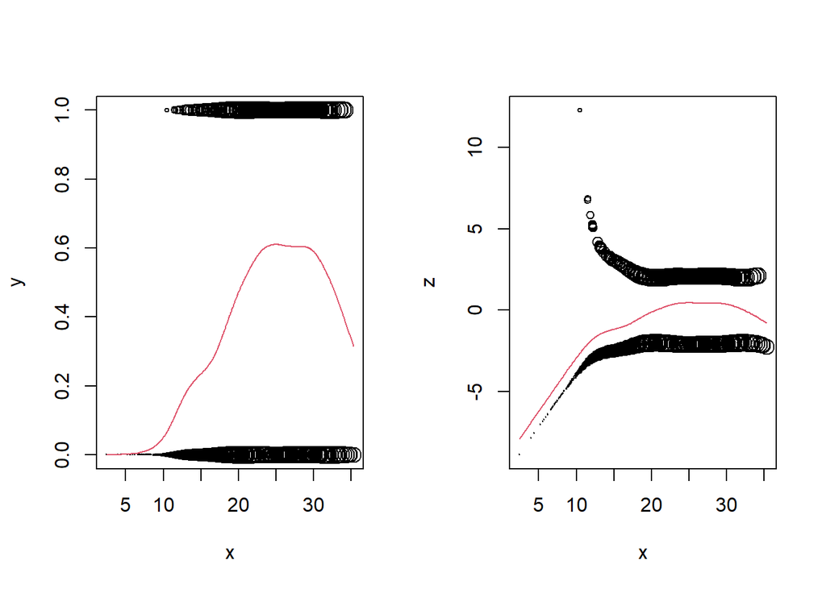

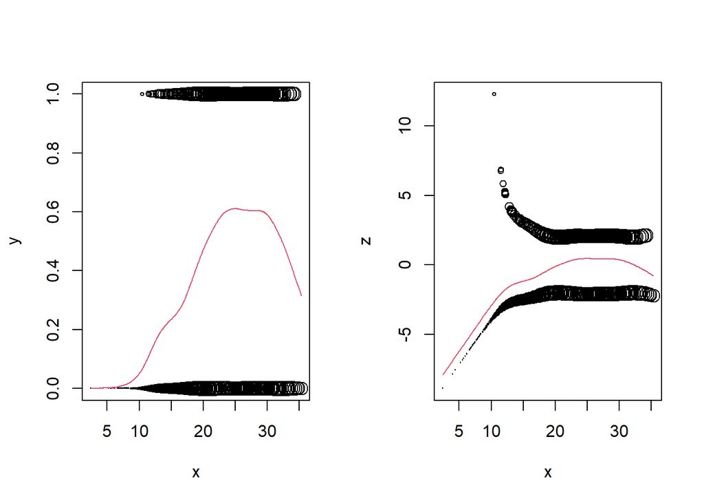

```r
# Sort dataframe based on the "instant" column
df <- bikes[order(bikes$temp), ]
# Fit logistic regression model with optimal df
final_model <- logistic.IRWLS.splines(x = df$temp,
                                       y = df$cnt.5000,
                                       df = optimal_df,
                                       plts=TRUE)
```

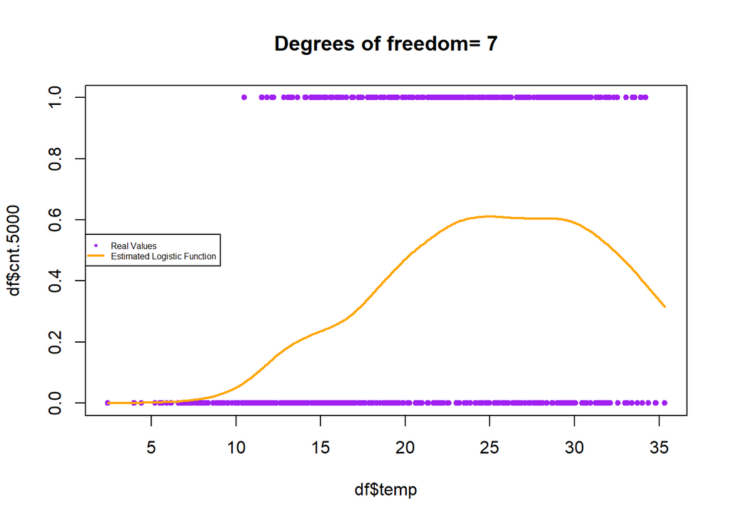

```r
plot(x = df$temp, y = df$cnt.5000,
     main=paste("Degrees of freedom=",round(optimal_df,2)), col = "purple", pch = 20)
# lines(bikes$temp,final_model$fitted.values>0.5,col="orange",lwd=2)
lines(df$temp,final_model$predicted.values,col="orange",lwd=2)
# Add legend with adjusted position
legend("left", legend = c("Real Values", "Estimated Logistic Function"), col = c("purple", "orange"), pch = c(20, NA), lwd = c(NA, 2), cex = 0.5)
```